# Aedes albopictus SNP chip - Ancetry analysis with Admixture.

## 4. Get the cross validation values

### 4.1 Neutral set

Collect the cross validation information from all the log files. We have to do it for each run. We need to get the CV and the K from each log file.

```bash
# navigate to the data directory
cd /gpfs/ycga/project/caccone/lvc26/admixture/neutral
# let's check the log files using grep. We need to get the line with the CV values. We can grep CV
grep CV run1/log*.txt | head
```

Make loop to get summary

```bash
cd /gpfs/ycga/project/caccone/lvc26/admixture/neutral
#
for i in $(ls -1 run1/log*.txt); do
    grep -H CV $i | sed 's|run| |' | sed 's|/log_k| |' | sed 's|.txt:CV error (K=| |' | sed 's|):||' | sed 's|_||' | awk '{print $1, $3, $4}'
done > cross_validation_neutral_set.txt
```

Download the data

```bash
rsync -chavzP --stats lvc26@mccleary.ycrc.yale.edu:/gpfs/ycga/project/caccone/lvc26/admixture/neutral/cross_validation_neutral_set.txt /Users/lucianocosme/Library/CloudStorage/Dropbox/Albopictus/manuscript_chip/data/no_autogenous/albo_chip/output/populations/admixture/neutral
```

Import the cross validation values into R

```r
cross_val_default <-
  read_delim(
    here(
      "output", "populations", "admixture", "neutral", "cross_validation_neutral_set.txt"
    ),
    col_names      = FALSE,
    show_col_types = FALSE,
    col_types      = "cin"
  ) |>
  rename(
    run = 1,
    k   = 2,
    cv  = 3
  )
```

Lets make cv plot for the default run

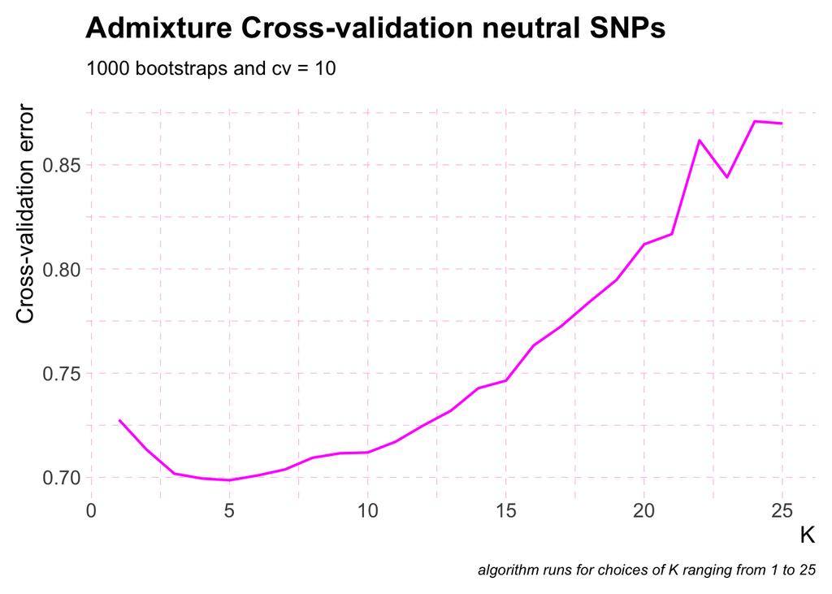

```r
cross_val_default |>
  ggplot() +
  geom_line(
    aes(
      x        = k,
      y        = cv
    ),
    linewidth  = .75,
    color = "magenta"
  ) +
  labs(
    x        = "K",
    y        = "Cross-validation error",
    title    = "Admixture Cross-validation neutral SNPs",
    subtitle = "1000 bootstraps and cv = 10 ",
    caption  = "algorithm runs for choices of K ranging from 1 to 25"
  ) +
  hrbrthemes::theme_ipsum(
    base_family      = "",
    axis_text_size   = 12,
    axis_title_size  = 14,
    plot_margin      = margin(10, 10, 10, 10),
    grid             = TRUE,
    grid_col         = "#fabbe2"
  ) +
  theme(
    panel.grid.major = element_line(
      linetype       = "dashed",
      linewidth      = 0.2,
    ),
    legend.title     = element_text(
        size           = 14,
        face           = "bold"
      ),
    panel.grid.minor = element_line(
      linetype       = "dashed",
      linewidth      = 0.2
    )
  )
```

```r
#
# save the plot
ggsave(
  here(
    "output", "populations","figures", "admixuture_default_run_k1_k25.pdf"
  ),
  width  = 8,
  height = 6,
  units  = "in"
)
```

Now we can find the K with the lowest cross-validation error

```r
cross_val_default |>
  summarize(
    LowestCVerror = min(
      cv,
      na.rm       = TRUE
    )
  ) -> cv_min_default

cross_val_default |>
  slice(
    which.min(
      cv
    )
  ) |>
  select(
    run, k, cv
  ) |>
  rename(
    LowestCVerror = 3
  ) -> k_with_lowest_cv_default


k_with_lowest_cv_default
```

```
## # A tibble: 1 × 3
##   run       k LowestCVerror
##   <chr> <int>         <dbl>
## 1 1         5         0.699
```

k=5

### 4.2 r2_0.01 snp set

Collect the cross validation information from the all the log files. We have to do it for each run. We need to get the CV and the K from each log file.

```bash
cd /gpfs/ycga/project/caccone/lvc26/admixture/r2_0.01
grep CV run1/log*.txt | head
```

Make loop to get the summary

```bash
cd /gpfs/ycga/project/caccone/lvc26/admixture/r2_0.01
#
for i in $(ls -1 run1/log*.txt); do
    grep -H CV $i | sed 's|run| |' | sed 's|/log_k| |' | sed 's|.txt:CV error (K=| |' | sed 's|):||' | sed 's|_||' | awk '{print $1, $3, $4}'
done > cross_validation_r2_0.01_set.txt
```

Download the data

```bash
rsync -chavzP --stats lvc26@mccleary.ycrc.yale.edu:/gpfs/ycga/project/caccone/lvc26/admixture/r2_0.01/cross_validation_r2_0.01_set.txt /Users/lucianocosme/Library/CloudStorage/Dropbox/Albopictus/manuscript_chip/data/no_autogenous/albo_chip/output/populations/admixture/r2_0.01
```

Import the cross validation values into R

```r
cross_val_default <-
  read_delim(
    here(
      "output", "populations", "admixture", "r2_0.01", "cross_validation_r2_0.01_set.txt"
    ),
    col_names      = FALSE,
    show_col_types = FALSE,
    col_types      = "cin"
  ) |>
  rename(
    run = 1,
    k   = 2,
    cv  = 3
  )
```

Lets make cv plot for the default run

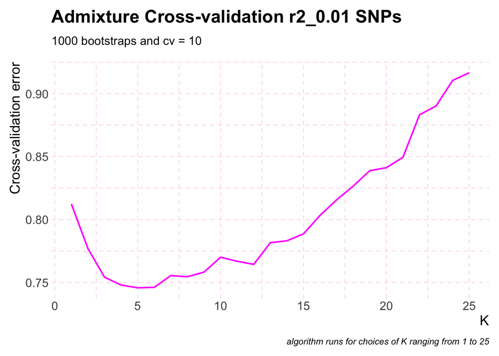

```r
# make plot
cross_val_default |>
  ggplot() +
  geom_line(
    aes(
      x        = k,
      y        = cv
    ),
    linewidth  = .75,
    color = "magenta"
  ) +
  labs(
    x        = "K",
    y        = "Cross-validation error",
    title    = "Admixture Cross-validation r2_0.01 SNPs",
    subtitle = "1000 bootstraps and cv = 10 ",
    caption  = "algorithm runs for choices of K ranging from 1 to 25"
  ) +
  hrbrthemes::theme_ipsum(
    base_family      = "",
    axis_text_size   = 12,
    axis_title_size  = 14,
    plot_margin      = margin(10, 10, 10, 10),
    grid             = TRUE,
    grid_col         = "#fabbe2"
  ) +
  theme(
    panel.grid.major = element_line(
      linetype       = "dashed",
      linewidth      = 0.2,
    ),
    legend.title     = element_text(
        size           = 14,
        face           = "bold"
      ),
    panel.grid.minor = element_line(
      linetype       = "dashed",
      linewidth      = 0.2
    )
  )
```

```r
#
# save the plot
ggsave(
  here(
    "output", "populations", "figures", "admixuture_r2_0.01_run_k1_k25.pdf"
  ),
  width  = 8,
  height = 6,
  units  = "in"
)
```

Now we can find the K with the lowest cross-validation error

```r
cross_val_default |>
  summarize(
    LowestCVerror = min(
      cv,
      na.rm       = TRUE
    )
  ) -> cv_min_default

cross_val_default |>
  slice(
    which.min(
      cv
    )
  ) |>
  select(
    run, k, cv
  ) |>
  rename(
    LowestCVerror = 3
  ) -> k_with_lowest_cv_default


k_with_lowest_cv_default
```

```
## # A tibble: 1 × 3
##   run       k LowestCVerror
##   <chr> <int>         <dbl>
## 1 1         5         0.746
```

k=5